# Beyond Equilibrium Systems

17 Nov 2020

# 1. Isotope flux at steady-state

The following schematic shows C4 type carbon fixation. The difference to C3 type carbon fixation is that CO2 is first bound to phosphoenolpyruvate (PEP) as bicarbonate in mesophyll cells to form oxaloacetate (OA). This makes it efficient to capture and transport the carbon to the bundle sheath cells where it is released again and can be fixed by RuBisCO in the Calvin cycle (same process in C3 photosynthesis) into biomass (the OA gets recycled back to PEP to capture more CO2 in the mesophyll cells). Because of this mechanism, the overall carbon fixation isotope effect can be quite different from C3-type photosynthesis despite the fact that both use the same enzyme to fix CO2 into biomass (RuBisCO).

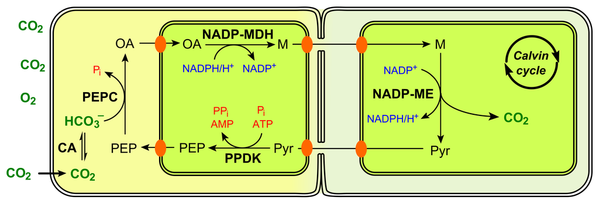

Here we will derive the steady-state solution for this system to interrogate the impact of key parameters $r=\frac{\phi_{out}}{\phi_{in}}$ (the ratio of the flux of CO2 into and out of the mesophyll cells, i.e. CO2 exchange) and $L=\frac{\phi_{leak}}{\phi_{PEP}}$ (the ratio of CO2 leakage flux out of the bundle sheath cells vs. flux of CO2 captured by PEP). The following schematic depicts the overarching metabolic flux diagram typically invoked for C4 type carbon fixation with fractionation factors $\epsilon_{diff, air}$ (kinetic fractionation for diffusion of CO2 gas into/out of the pore space of the mesophyll cells), $\epsilon_{diff, H2O}$ (kinetic fractionation for diffusion of CO2 in water inside the cells), $\epsilon_{HCO2/CO2}$ (equilibrium fractionation between bicarbonate and CO2), $\epsilon_{PEP}$ (enzymatic fractionation when PEP binds bicarbonate), and $\epsilon_{fix}$ (enzymatic fractionation of CO2 fixation by RuBisCO):

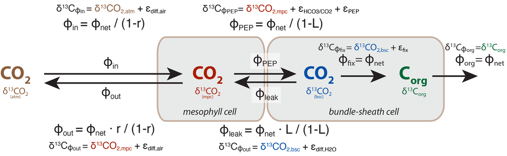

## 1A: $C_{org}$ node

Write out the rate of change equations for the $C_{org}$ node and use the assumption of steady-state to find an expression for $\delta^{13}CO_{2,bsc}$ (CO2 in the bundle sheath cells) as a function of $\delta^{13}C_{org}$ and $\epsilon_{fix}$.

$$\begin{aligned}
\frac{d[C_{org}]}{dt} &= \\
\frac{d([C_{org}] \delta^{13}C_{org})}{dt} &= \\
\rightarrow \delta^{13}CO_{2,bsc} &=
\end{aligned}$$

## 1B: $CO_{2,bsc}$ node

Write out the rate of change equations for the $\delta^{13}CO_{2,bsc}$ node (CO2 in bundle sheath cells) and use the assumption of steady-state as well as the equation for $\delta^{13}CO_{2,bsc}$ derived above, to find an expression for $\delta^{13}CO_{2,mpc}$ as a function of $\delta^{13}C_{org}$, fractionation factors $\epsilon_{fix}$, $\epsilon_{HCO3/CO2}$, $\epsilon_{PEP}$, and $\epsilon_{diff, H2O}$, and leakage $L$.

> Hint: with the fluxes already provided in terms of net flux $\phi_{net}$, you will not need the mass flux equation to solve this.

$$\begin{aligned}
\frac{d[CO_{2,bsc}] \delta^{13}CO_{2,bsc}}{dt} &= \\
\rightarrow \delta^{13}CO_{2,mpc} &=
\end{aligned}$$

## 1C: $CO_{2,mpc}$ node

> Hint: again, with the fluxes already provided in terms of net flux $\phi_{net}$, you will not need the mass flux equation to solve this. Also, you can simplify the initial equation by recognizing that at steady-state the terms describing the flux **out of** the $\delta^{13}CO_{2,mpc}$ node are the same terms describing the flux **into** the $\delta^{13}CO_{2,bsc}$ node (and thus can be set equal to the flux term **out of** the $\delta^{13}CO_{2,bsc}$ node).

$$\begin{aligned}
\frac{d[CO_{2,mpc}] \delta^{13}CO_{2,mpc}}{dt} &= \\
\rightarrow \delta^{13}CO_{2,atm} &= \\
\rightarrow \epsilon_{org/CO_2} = \delta^{13}C_{org} - \delta^{13}CO_{2,atm} &=
\end{aligned}$$

## 1D: The effects of reversibility in C3 and C4 plants

Compare the effect of reversibility ($r$, from 0 to 1 - 0% to 100%) in C3 and C4 plants (equations summarized below) on $\epsilon_{org/CO_2}$ with the following fractionation factors (common values at 25C). For this exercise, assume C4 plants are perfectly efficient with no leakage from the bundle sheath cells ($L=0$). Store the resulting tibble in variable `df_1d` (with, at minimum, columns `r`, `C3_eps_org_vs_atm` and `C4_eps_org_vs_atm`) and make a plot of $C3_eps_org_vs_atm$ and $C4_eps_org_vs_atm$ (use `pivot_longer`) vs. `r` stored in variable `p_1d`.

Based on the plot, answer the following discussion question:

**How does CO2 exchange (reversibility parameter `r`) affect the net fractionation in C3 and C4 plants?**

```r
tibble(
  eps_HCO3_CO2 = 7.9, # in permil
  eps_PEP = -2.2, # in permil
  eps_diff_water = -0.8, # in permil
  eps_diff_air = -4.4, # in permil
  eps_fix = -25 # in permil
)
```

$$\begin{aligned}
\text{C3}:&\\
&\epsilon_{org/CO_2} =
\delta^{13}C_{org} - \delta^{13}CO_{2,atm} =
\epsilon_{diff,air} + r \cdot (\epsilon_{fix} - \epsilon_{diff,air}) \\
\text{C4}:&\\
&\epsilon_{org/CO_2} =
\delta^{13}C_{org} - \delta^{13}CO_{2,atm} =
\epsilon_{diff,air} + r \cdot (\epsilon_{HCO3/CO2} + \epsilon_{PEP} + L \cdot (\epsilon_{fix} - \epsilon_{diff, H2O}) - \epsilon_{diff,air})
\end{aligned}$$

```r
df_1d <-
  tibble(
    ?
  )

p_1d <- ?
p_1d
```

## 1E: The effects of leakage (L) in C4 plants

Although C4 plants are highly efficient, they are not 100% so and some of the CO2 captured by PEP and delivered to RuBisCO can escape back out of the cells without getting fixed. This means that the leakage $L$ in most real C4 plants is > 0 (e.g. corn has about $L=0.27$). Repeat the calculations from the previous exercise ($r$ from 0 to 1 for both C3 and C4 plants) but with four different leakage scenarios ($L$ = 0, 0.27, 0.41 and 1). Store the resulting tibble in variable `df_1e` (with, at minimum, columns `r`, `L`, `C3_eps_org_vs_atm` and `C4_eps_org_vs_atm`) and make a plot of $C3_eps_org_vs_atm$ and $C4_eps_org_vs_atm$ (use `pivot_longer`) vs. `r` with an aesthetic for $L$ (recommend `linetype`, especially if you are already using color to for C3 vs C4) stored in variable `p_1e`. Hint: use `crossing(r = seq(0, 1, by = 0.1), L = c(0, 0.27, 0.41, 1))` to generate all combinations of `r` and `L`; use `factor(L)` to turn the number into a discrete variable for aesthetic mapping.

Based on the plot, answer the following discussion question:

**How does leakage (`L`) affect the net fractionation in C3 and C4 plants?**

```r
df_1e <- ?

p_1e <- ?

p_1e
```

## 1F: which is C3 and which is C4?

Farquhar et al., 1989 plotted a similar graph (reversibility vs. net fractionation) for different plants. Note that normal fractionation factors are plotted as positive values, i.e. opposite to the exercises above. The CO2 exchange/reversibility (x-axis) is measured in terms of internal (Pi) vs. external (Pa) partial pressure of CO2 which is functionality equivalent to reversibility $r$ in the exercises above (since CO2 diffusion in and out of the plant is driven solely by the pressure gradient). Which plant(s) are C3 and which plant(s) are C4? Clearly explain your reasoning based on these data.

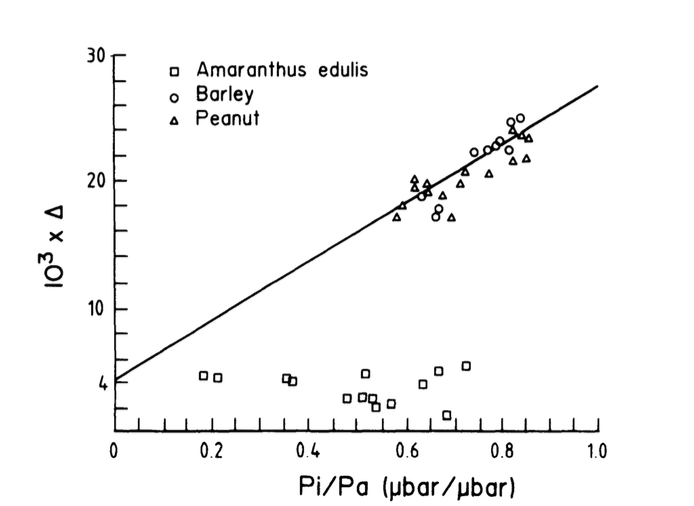

# 2. Non steady-state systems

The following system simulates a cow eating a meal and then digesting it happily and converting it into biomass, respired CO2 and microbial fermentation products (some of which the cow can use, some of which are just excreeted as microbial biomass and most of which are reworked to CO2 and methane by the microbial community). Here, we are using the custom package `isocyclr` just to make it easier to set up the whole system and run a simulation. All reaction kinetics are modeled as first order kinetics from the precursor pool with the same rate constant `k`.

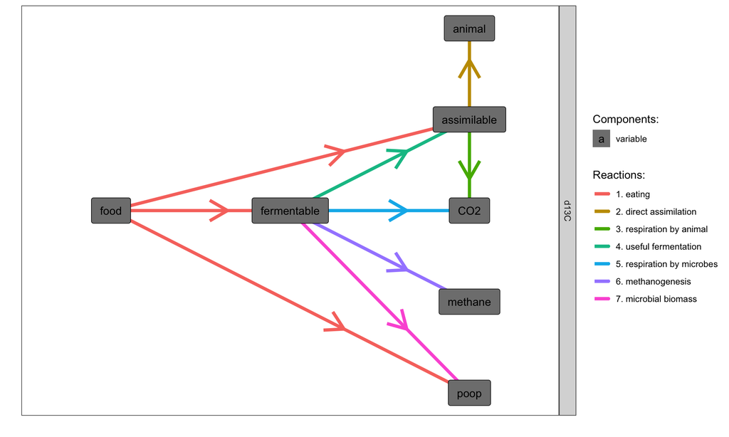

```r
library(isocyclr)

cow <- isopath() %>%
  add_isotope("d13C") %>%
  add_component(
    c("food", "assimilable", "fermentable", "animal", "poop", "CO2", "methane"),
    d13C) %>%
  # food intake
  add_custom_reaction(
    food == 0.4 * assimilable + 0.5 * fermentable + 0.1 * poop,
    flux = k * food, flux.d13C = food.d13C, name = "1. eating") %>%
  # assimilable fractoin
  add_custom_reaction(
    assimilable == animal, name = "2. direct assimilation",
    flux = 0.2 * k * assimilable, flux.d13C = assimilable.d13C) %>%
  add_custom_reaction(
    assimilable == CO2, name = "3. respiration by animal",
    flux = 0.8 * k * assimilable, flux.d13C = assimilable.d13C - 1.5) %>%
  # fermentable fraction
  add_custom_reaction(
    fermentable == assimilable, name = "4. useful fermentation",
    flux = 0.1 * k * fermentable, flux.d13C = fermentable.d13C) %>%
  add_custom_reaction(
    fermentable == CO2, name = "5. respiration by microbes",
    flux = 0.43 * k * fermentable, flux.d13C = fermentable.d13C - 1.5) %>%
  add_custom_reaction(
    fermentable == methane, name = "6. methanogenesis",
    flux = 0.43 * k * fermentable, flux.d13C = fermentable.d13C - 70) %>%
  add_custom_reaction(
    fermentable == poop, name = "7. microbial biomass",
    flux = 0.04 * k * fermentable, flux.d13C = fermentable.d13C)

cow %>% generate_reaction_diagram(add_arrows = T)
```

## 2A: What does the cow system look like?

Based on this reaction schematic and the different flux proportions and isotopic effects indicated in the above reactions, draw a diagram for this system labeling the pools (like in the diagram in the previous problem), the relative fluxes, and the formulas for the isotopic composition of the fluxes. (*Note: name the file `cow_solution.jpg` or `cow_solution.png` - totally sufficient to take a picture of your sketch with an in-focus phone camera and upload the picture into this assignment repository.*).

## 2B: Watching the cow eat

Now that the system is set up, we will use it to numerically run through the scenario of feeding the cow with 100 **Moo** (the internationally recognized mass unit for cow food), here represented with setting the initial size of the `food` pool to 100 (note that the other pools can’t quite be zero because we’d run into numerical problems simulating the flux from the initial condition but we’re setting them to virtually 0 by assigning pool sizes of $10^{-10}$ **Moo**). We’re also assuming an isotopic composition of 0‰ starting out and are running the simulation long enough until virtually all of the `food` pool is gone. The following plot illustrates how the individual pool sizes and isotopic compositions change as a function of the `food` pool remaining. Examine the graph and answer the following questions (qualitatively):

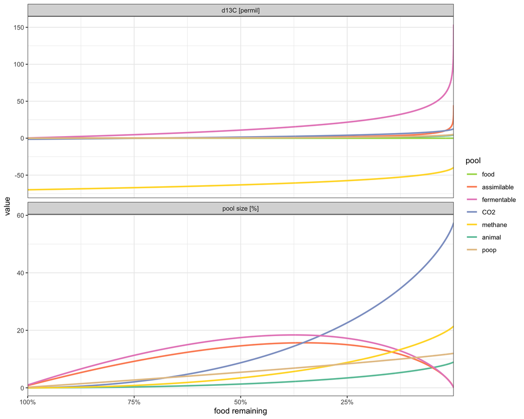

## 2C: Final pool distributions

The `result` variable holds the output of the simulation (for all 1000 time steps) with the last row (retrieved by `tail(n=1)`, see below) holding the state of the `cow` system at the very end of the simulation. Demonstrate that both mass and isotopic composition are conserved (to 4 decimal places) by calculating the summary columns `mass` and `isotopes` (store in a new data frame called `df_2c`).

What are the final pool sizes of the products (`CO2`, `methane`, `animal` and `poop`) to 1 decimal place? Show for each of these pools that this result is consistent with the flux partitioning through the reaction network (simple calculations but be mindful of sequential branchpoints and multiple paths contributing to some of these).

```r
df_2c <- result %>%
  tail(n = 1) %>%
  mutate(
    ?
  )

df_2c
```

# 3. OPTIONAL: Mass scaling laws and mass-independent isotope effects

Isotope effects for systems with more than 2 isotopes usually scale in certain way between multiple isotopes. Usually this scaling number is called the **mass scaling factor** or **coefficient** and designated by the letter $\kappa$, $\lambda$ or (most confusingly) $\beta$. We’ll definitely avoid the last one because this is *not* the same as the reduced partition function ratio and instead settle on $\lambda$ for this exercise (but you may encounter the others in the literature).

If $\alpha$ describes how **2 isotopes** (e.g. $^{16}O$ and $^{18}O$) fractionate in a process, the scaling factor (here $\lambda$) describes how fractionation in that process is related for **3 isotopes** (e.g. $^{16}O$, $^{17}O$, $^{18}O$), usually by relating the fractionation factor for the rarer minor isotope (here, $^{17/16}\alpha$) is related to that of the typical minor isotope ($^{18/16}\alpha$):

$$^{17/16}\alpha = (^{18/16}\alpha)^\lambda \rightarrow (\delta^{17}O + 1) = (\delta^{18}O + 1)^\lambda$$

For equilibrium processes, $\lambda$ can be calculated from the ratios of the ratios of the partition function ratios (…so many ratios…), which fortunately simplifies to the following approximation:

$$\lambda = \frac{\frac{1}{m_1} - \frac{1}{m_2}}{\frac{1}{m_1} - \frac{1}{m_3}}$$

Where masses 1, 2 and 3 are simply the three isotopes, i.e. for oxygen, $m_1 = 16$, $m_2 = 17$, $m_3 = 18$ and $\lambda_{eq}$=0.5294

For kinetic processes, however, a better approximation is:

$$\lambda = \frac{\ln{m_1} - \ln{m_2}}{\ln{m_1} - \ln{m_3}}$$

which, for oxygen evaluates to $\lambda_{kin}$=0.5147. The equilibrium and kinetic scaling factors are similar but not identical. As a consequence, most environmental processes that are a combination of several steps have a scaling factor somewhere in between. For the process of respiration, for example, $\lambda_{resp}$ is 0.5179 (*Kaiser, 2011: Consistent calculation of aquatic gross production from oxygen triple isotope measurements.*).

## 3A: Scaling factors for sulfur

Using the equations above, write a function each (`calc_eq_scaling` and `calc_kin_scaling`) to calculate predicted equilibrium and kinetic scaling factors and use them to calculate both for sulfur 32, 33, 34 (*Note: sulfur also has a forth isotope 36 so this calculation could also be performed for 32, 36, 34 instead*).

```r
# approximation for eq. effects
calc_eq_scaling <- function(m1, m2, m3)  {

}

# approximation for kinetic effects
calc_kin_scaling <- function(m1, m2, m3) {

}

calc_eq_scaling(32, 33, 34)
calc_kin_scaling(32, 33, 34)
```

## 3B: Mass-scaling in equilibrium processes

Assume a material with isotopic composition $\delta^{34}S = 0$ and $\delta^{33}S = 0$ is fractionated by different equilibrium processes that have $^{34}\epsilon_{product/reactant}$ values ranging from -60‰ to +60‰ (in steps of 10‰).

Calculate the set of $^{34}\alpha$ and $^{33}\alpha$ fractionation factors that correspond to these $^{34}\epsilon$ values using the exact scaling relation ($^{33}\alpha = (^{34}\alpha)^x$) with x=0.515 (i.e. the scaling factor for equilibrium processes), and apply these fractionation factors to the starting material to calculate the resulting $\delta^{34}S$ and $\delta^{33}S$. Store the result in a data frame named `df_3b` with (at minimum) columns `eps34`, `alpha34`, `alpha33`, `delta34`, and `delta33`. Plot the resulting $\delta^{33}S$ vs. $\delta^{34}S$ values and store the plot in `p_3b`.

```r
df_3b <- ?
df_3b

p_3b <- ?
p_3b
```

## 3C: Mass-scaling in diverse processes

Most natural processes follow mass scaling laws with scaling coefficients in the range of the predicted kinetic to equilibrium value but there are some (such as quantum tunnling and certain photochemical reactions) that do not. Those are frequently termend mass-‘independent’ processes, which is a bit misleading because they are often still influenced by the difference in mass between the isotopes, they just don’t follow the predicted scaling relationship (i.e. may have a totally different scaling factor from the equilibrium or kinetic one).

The new pools with varying $\delta^{34}S$ (and $\delta^{33}S$) values you just calculated in the previous section (`df_3b`) are now affected by a single second process with fixed $^{34}\epsilon_{product/reactant}$ = 20‰ but in 3 different scaling scenarios. For each scenario, calculate the resulting $^{33}\alpha$ value and apply the $^{34}\alpha$ and $^{33}\alpha$ fractionation factor to the isotopic compositions calculated in the previous section (use the exact formula $\delta_{product} = \alpha_{product/reactant} \cdot (\delta_{reactant} + 1) - 1$ for fractionation, not the $\delta_{product} = \delta_{reactant} + \epsilon_{product/reactant}$ approximation). Again, store the result in data frame `df_3c` with (at minimum) added columns `new_delta34` and `new_delta33`, and plot $\delta^{33}S$ vs. $\delta^{34}S$ for the resulting values with all scenarios on the same plot (store the plot in `p_3c`).

- 1. another equilibrium process with mass scaling factor for sulfur-33 of x=0.515
- 2. a kinetic process with mass scaling factor for sulfur-33 of x=$\lambda_{kin}$ that you calculated earlier
- 3. some photolytic process with a scaling factor of 0.950

> Answer:

```r
df_3c <- ?
df_3c

p_3c <- ?
p_3c
```

## 3D: Quantifying ‘mass-independent’ fractionation (MIF)

Regardless of semantic discussions about the term “mass-indepenent”, there needs to be some way to determine whether a sample does or doesn’t follow the expected mass scaling law since this can give important hints as to what kind of processes may have affected the sample. Typically, this is done in several possible ways that all describe a **deviation** from the expected mass scaling law (with the deviation termed capital delta $\Delta^{x}E$, i.e. $\Delta^{17}O$ or $\Delta^{33}S$, *Note: not to be confused with $\Delta_{A/B}$ as an approximation for a fractionation factor!*). The deviation from expection is either defined as the difference between measured and expected delta values, or as the relative difference of observed from expected fractionation factors, i.e., the following two are the commonly used notations (subscripted I and II, respectively, here with the example of sulfur-33 to make it more concrete):

$$\begin{align}
\Delta^{33}S_I &\equiv \delta^{33}S_{obs} - \delta^{33}S_{expect} = \delta^{33}S_{obs} - ((\delta^{34}S_{obs} + 1)^\lambda - 1) = \delta^{33}S_{obs} + 1 - (\delta^{34}S_{obs} + 1)^\lambda \\
\Delta^{33}S_{II} &\equiv \frac{^{33}\alpha_{obs} - \vphantom{a}^{33}\alpha_{expect}}{^{33}\alpha_{expect}} = \frac{\delta^{33}S_{obs} + 1}{(\delta^{34}S_{obs} + 1)^\lambda} - 1
\end{align}$$

The second one is frequently cast by taking natural logs and further simplified approximating $\ln (x+1) \approx x$ for $x\ll1$ (similar to what we’ve seen for fractionation factors), leading to $\Delta$ definitions III and IV (especially IV is a popular simplification you see all the time):

$$\begin{align}
\Delta^{33}S_{III} &\equiv \ln{(\delta^{33}S_{obs} + 1)} - \lambda \cdot \ln{(\delta^{34}S_{obs} + 1)} \\
\Delta^{33}S_{IV} &\equiv \delta^{33}S_{obs} - \lambda \cdot \delta^{34}S_{obs}
\end{align}$$

For each scenario you calculated in part C, calculate and plot the $\Delta^{33}S$ (*1000 to illustrate in ‰) vs. $\delta^{34}S$ with all 4 definitions of $\Delta$ (use the standard mass scaling for sulfur-33 for the $\Delta$ calculations of $\lambda$ = 0.515). Store the resulting data frame in `df_3d` with (at minimum) new columns `D33_1`, `D33_2`, `D33_3`, `D33_4` (for the 4 definitions) and the plot in `p_3d`. Hint: use `gather(..., starts_with("D33"))` for easy plotting.

For all 3 scenarios, comment on what you would expect $\Delta^{33}S$ to be (qualitatively, i.e. 0, positive, negative?) and what you observe for the 4 definitions of $\Delta$. Which definitions are problematic to use?

```r
df_3d <- ?
df_3d

p_3d <- ?
p_3d
```

# 5. Code checks